# CMSC320: 0101: Final Project

Houses in California

#### By Ashmita Roy

Introduction:

Who doesn’t dream of owning a house in the Bay Area?! California is a dream for homeowners and this dream shows no signs of dying down. However, this poster (showing land companies putting out advertisements to attract homeowners to California) dated 12 October 1876 tells us that it was not always so!

[figure not shown]

We will use the Housing Data for California dataset (containing information from the 1990 California census) to investigate this. Initially this tutorial walks you through the process of cleaning the available data, some visualisation of the data for exploratory analysis and then follow it up with some models to predict the value of a house in a particular block/location of California.

##### This tutorial walks you through the process of the Data Science Pipeline:

- Gathering, parsing and cleaning available data: on Housing Blocks in California from 1990
- Exploratory data analysis and data visualisation : See the dataset in a visual form with plots and get an image of what the values are typically.
- Statistical and Machine Learning : Make predictions about attributes of the dataset using other attributes and then check how accurate our predictions , using a model were.

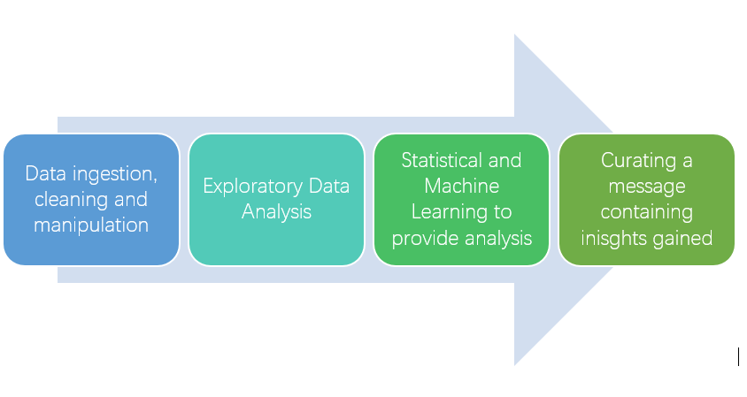

### Pre-requisites:

- R or RStudio
- **Packages in R are third-party add-ons that allow a multitude of actions. To install a package**

  Open RStudio or R and type the following into the console:
- Install the following packages:
  - tidyverse
  - reshape2
  - boot
  - randomForest
  - coefplot

```r
#loading the packages we've installed
library(tidyverse)
library(reshape2)
```

## Data Ingestion, Cleaning

With any task, the quality of the output depends on the quality of the inputs. Thus, gathering, cleaning and preparing data in any project is of immense importance.

## Initialisation:

### Step 1

- GATHER DATA

Download the dataset( available as a CSV file named housing.csv ) from https://www.kaggle.com/camnugent/california-housing-prices/downloads/california-housing-prices.zip/1

- INGEST AND PARSE DATA

The readr R package, included in our tidyverse package allows us to use read_csv to read a dataset in a CSV(comma-separated-value) file.  
[ Ensure that you have downloaded your dataset into your current working directory.] .  
You can READ more about the readr package [here](https://cran.r-project.org/web/packages/readr/index.html)

```r
#to read the CSV file, located in the current working directory
housing = read.csv('housing.csv')

#to display the first few records from all the columns, a glance at the data itself
head(housing)
```

```
##   longitude latitude housing_median_age total_rooms total_bedrooms
## 1   -122.23    37.88                 41         880            129
## 2   -122.22    37.86                 21        7099           1106
## 3   -122.24    37.85                 52        1467            190
## 4   -122.25    37.85                 52        1274            235
## 5   -122.25    37.85                 52        1627            280
## 6   -122.25    37.85                 52         919            213
##   population households median_income median_house_value ocean_proximity
## 1        322        126        8.3252             452600        NEAR BAY
## 2       2401       1138        8.3014             358500        NEAR BAY
## 3        496        177        7.2574             352100        NEAR BAY
## 4        558        219        5.6431             341300        NEAR BAY
## 5        565        259        3.8462             342200        NEAR BAY
## 6        413        193        4.0368             269700        NEAR BAY
```

This tells us that the dataset describes houses and their occupants.  
It is evident that each row is denoting a certain block of households.  
By now, we have taken a peek at the data.  
Now, we attempt to get a gist of the dataset we are dealing with.

```r
#summarized description of the attributes
summary(housing)
```

```
##    longitude         latitude     housing_median_age  total_rooms
##  Min.   :-124.3   Min.   :32.54   Min.   : 1.00      Min.   :    2
##  1st Qu.:-121.8   1st Qu.:33.93   1st Qu.:18.00      1st Qu.: 1448
##  Median :-118.5   Median :34.26   Median :29.00      Median : 2127
##  Mean   :-119.6   Mean   :35.63   Mean   :28.64      Mean   : 2636
##  3rd Qu.:-118.0   3rd Qu.:37.71   3rd Qu.:37.00      3rd Qu.: 3148
##  Max.   :-114.3   Max.   :41.95   Max.   :52.00      Max.   :39320
##
##  total_bedrooms     population      households     median_income
##  Min.   :   1.0   Min.   :    3   Min.   :   1.0   Min.   : 0.4999
##  1st Qu.: 296.0   1st Qu.:  787   1st Qu.: 280.0   1st Qu.: 2.5634
##  Median : 435.0   Median : 1166   Median : 409.0   Median : 3.5348
##  Mean   : 537.9   Mean   : 1425   Mean   : 499.5   Mean   : 3.8707
##  3rd Qu.: 647.0   3rd Qu.: 1725   3rd Qu.: 605.0   3rd Qu.: 4.7432
##  Max.   :6445.0   Max.   :35682   Max.   :6082.0   Max.   :15.0001
##  NA's   :207
##  median_house_value   ocean_proximity
##  Min.   : 14999     <1H OCEAN :9136
##  1st Qu.:119600     INLAND    :6551
##  Median :179700     ISLAND    :   5
##  Mean   :206856     NEAR BAY  :2290
##  3rd Qu.:264725     NEAR OCEAN:2658
##  Max.   :500001
##
```

```r
#to get an idea about all the columns in the dataset, we check the Column Names
colnames(housing)
```

```
##  [1] "longitude"          "latitude"           "housing_median_age"
##  [4] "total_rooms"        "total_bedrooms"     "population"
##  [7] "households"         "median_income"      "median_house_value"
## [10] "ocean_proximity"
```

## **Data Exploration and Visualization**

Exploring data visually is a considerably important initial step. Visualization gives us the chance to pinpoint structure, similarities, potential relationships and aberrations in the dataset. Quite commonly, no further formal analysis is required as visual data exploration aids the user fully.  
Else, it acts as a vital stepping stone to future formal analyses.

Now an attempt can be made to transform this dataset into a graphical form, so it is easy to grasp as a visual concept.  
We do this using ggplot (which was included in our tidyverse package) to create histograms for each attribute. This cheatsheet can help while using ggplot https://www.rstudio.com/wp-content/uploads/2015/03/ggplot2-cheatsheet.pdf

### 2.1 Creating plots to visualise the dataset:

### Histogram showing the median house value for households within a block (measured in US Dollars)

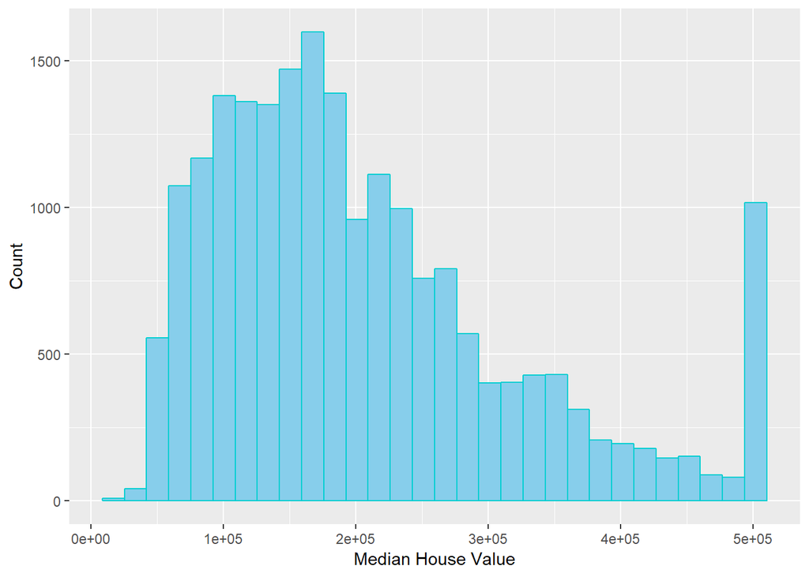

```r
#adding colour to the histogram
barfill="#87CEEB"
baroutline="#00ced1"

#Creating a histogram where median_house_value is plotted along the X axis
hist <- ggplot(housing, mapping=aes(x=median_house_value)) + geom_histogram( colour= baroutline, fill=barfill, alpha=1 ) + scale_x_continuous(name = "Median House Value") + scale_y_continuous(name = "Count")
hist
```

**NOTE:**

- We see that the median_house_value ie the value of the house seems to be capped at a certain maximum value, which we must remember to allow for in our analysis.
- Various colours can be added to plots to add dimension and interactivity.  
  Obtain the pertinent colour codes from https://www.color-hex.com/
- In the next few plots, we will use a **gradient of colours** to enhance the histogram’s visual impact.  
  You can learn more about this [here](http://t-redactyl.io/blog/2016/02/creating-plots-in-r-using-ggplot2-part-7-histograms.html).

### Histogram showing the total number of rooms

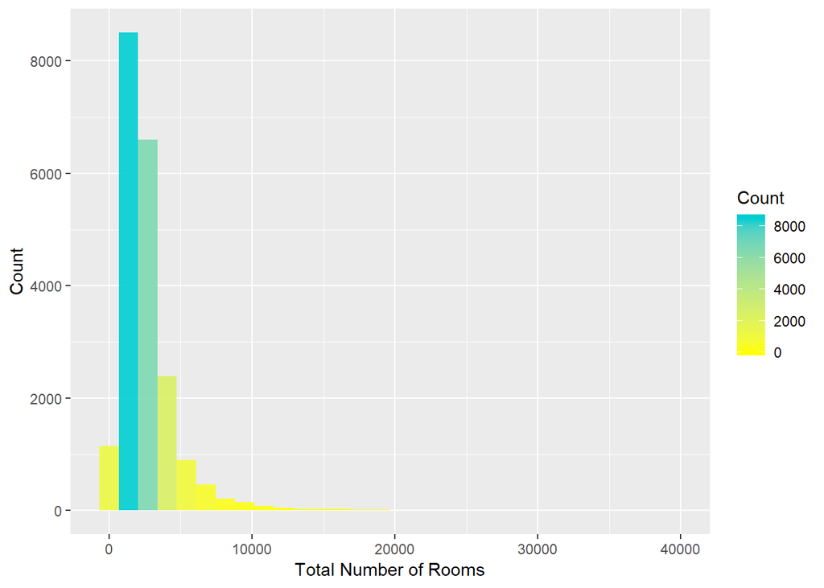

```r
#Creating a histogram where total_rooms is plotted along the X axis
hist <- ggplot(housing, mapping=aes(x=total_rooms, fill=..count..)) + geom_histogram( alpha=0.9 ) + scale_x_continuous(name = "Total Number of Rooms") + scale_y_continuous(name = "Count") +scale_fill_gradient("Count", low = "yellow", high = "#00ced1")
hist
```

#### **NOTE**:

This dataset provides us with total number of rooms for a housing block, which, intuitively might not seem very useful, given that our intention here is to predict the value of a house, we will look into how we might convert this into a value for a housing unit as opposed to an entire block.

### Histogram showing the distribution of median income for households within a block of houses (measured in tens of thousands of US Dollars)

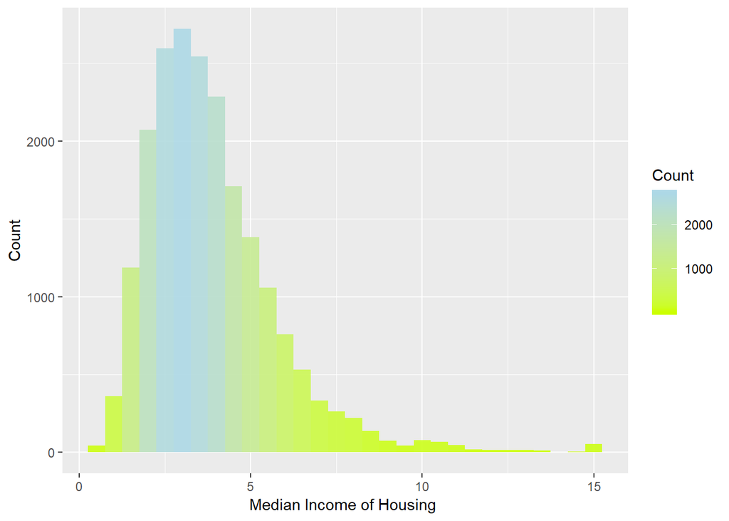

```r
#Creating a histogram where median_income is plotted along the X axis
hist <- ggplot(housing, mapping=aes(x=median_income, fill=..count..)) + geom_histogram( alpha=0.9 ) + scale_x_continuous(name = "Median Income of Housing ") + scale_y_continuous(name = "Count") +scale_fill_gradient("Count", low = "#ccff00", high = "lightblue")
hist
```

### Histogram showing the distribution of age across housings

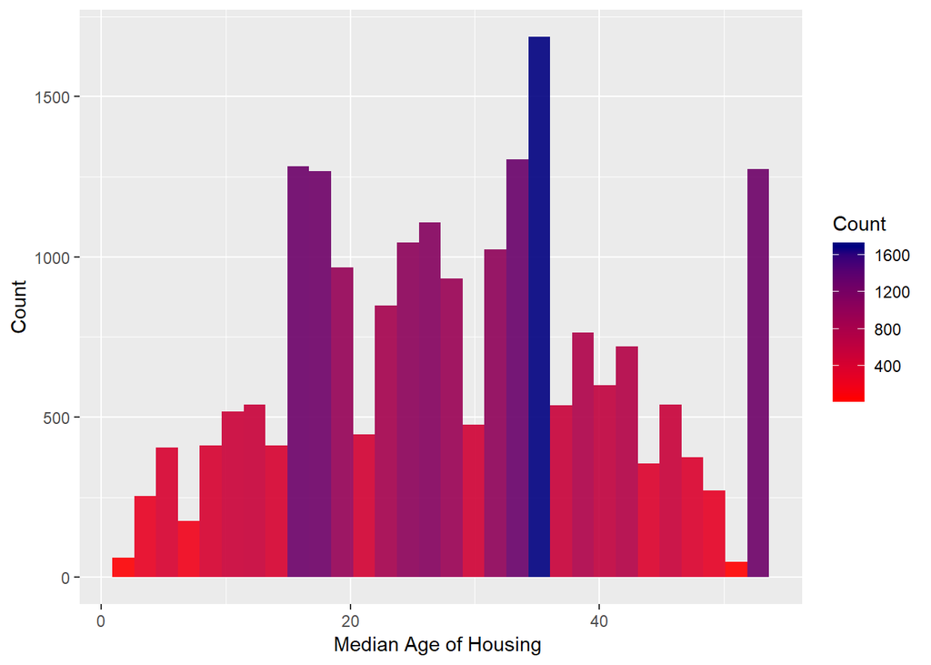

```r
#Creating a histogram where housing_median_age is plotted along the X axis
hist <- ggplot(housing, mapping=aes(x=housing_median_age, fill=..count..)) + geom_histogram( alpha=0.9 ) + scale_x_continuous(name = "Median Age of Housing ") + scale_y_continuous(name = "Count") +scale_fill_gradient("Count", low = "red", high = "navy")
hist
```

### Histogram showing the total number of bedrooms

```
## Warning: Removed 207 rows containing non-finite values (stat_bin).
```

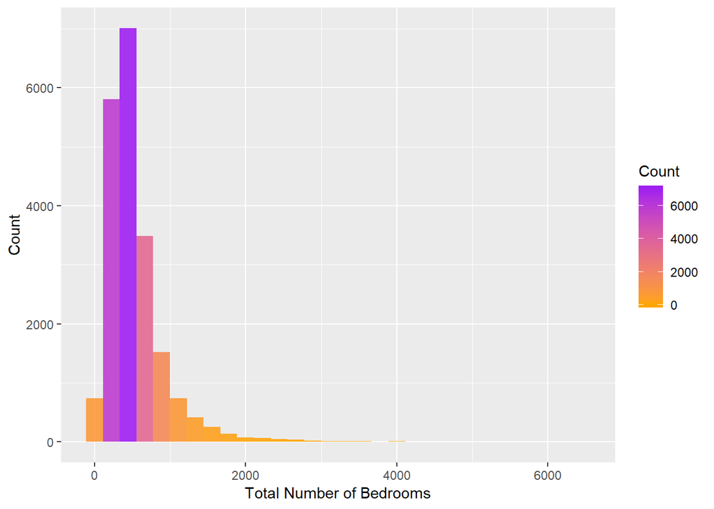

```r
#adding colour to the histogram

#Creating a histogram where total_bedrooms is plotted along the X axis
hist <- ggplot(housing, mapping=aes(x=total_bedrooms, fill=..count..)) + geom_histogram( alpha=0.9 ) + scale_x_continuous(name = "Total Number of Bedrooms") + scale_y_continuous(name = "Count") +scale_fill_gradient("Count", low = "orange", high = "purple")
hist
```

#### **NOTE**

The warning we received after plotting the histogram for the **total_bedrooms** attribute :  
(`Removed 207 rows containing non-finite values (stat_bin)`)  
tells us that missing values exist, which we will impute in our next step.

### Histogram showing the distribution of population across housing blocks

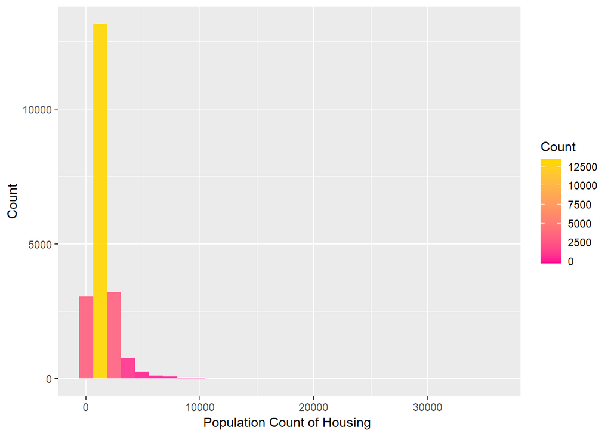

```r
#Creating a histogram where population is plotted along the X axis
hist <- ggplot(housing, mapping=aes(x=population, fill=..count..)) + geom_histogram( alpha=0.9 ) + scale_x_continuous(name = "Population Count of Housing ") + scale_y_continuous(name = "Count") +scale_fill_gradient("Count", low = "#ff1493", high = "gold1")
hist
```

### Histogram showing the distribution of number of households across housing blocks

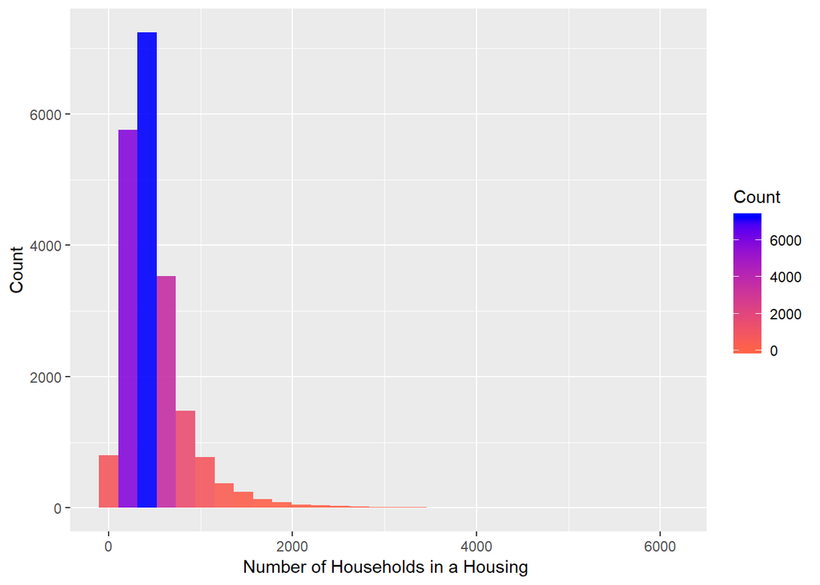

```r
#Creating a histogram where households is plotted along the X axis
hist <- ggplot(housing, mapping=aes(x=households, fill=..count..)) + geom_histogram( alpha=0.9 ) + scale_x_continuous(name = "Number of Households in a Housing ") + scale_y_continuous(name = "Count") +scale_fill_gradient("Count", low = "tomato", high = "blue")
hist
```

#### The above seemingly random attempts at visualising our dataset may not seem intuitive or helpful at this point, but they offer us multiple takeaways:

It is necessary for us to resolve the following issues:

- Issue 1. Impute missing values like N/A that exist in the dataset.
- Issue 2. The ranges for the variables vary hugely, thus we require to standardize the scale of the data when we use any non-tree based methods
- Issue 3. It is noticeable that the columns involve the total number of rooms, bedrooms which we woud prefer to convert to a mean value for that housing block.
- Issue 4: Categorical columns need to be converted into a type that can be handled and manipulated more easily.

### Step 2.2 Cleaning the data based on insights from the visualisations carried out:

#### Resolving Issue 1:

Here we fill in the missing values with the median of the column for total_bedrooms. For more help on imputing missing/erroneous values, see [here](https://medium.com/coinmonks/dealing-with-missing-data-using-r-3ae428da2d17).

```r
summary(housing)
```

```
##    longitude         latitude     housing_median_age  total_rooms
##  Min.   :-124.3   Min.   :32.54   Min.   : 1.00      Min.   :    2
##  1st Qu.:-121.8   1st Qu.:33.93   1st Qu.:18.00      1st Qu.: 1448
##  Median :-118.5   Median :34.26   Median :29.00      Median : 2127
##  Mean   :-119.6   Mean   :35.63   Mean   :28.64      Mean   : 2636
##  3rd Qu.:-118.0   3rd Qu.:37.71   3rd Qu.:37.00      3rd Qu.: 3148
##  Max.   :-114.3   Max.   :41.95   Max.   :52.00      Max.   :39320
##
##  total_bedrooms     population      households     median_income
##  Min.   :   1.0   Min.   :    3   Min.   :   1.0   Min.   : 0.4999
##  1st Qu.: 296.0   1st Qu.:  787   1st Qu.: 280.0   1st Qu.: 2.5634
##  Median : 435.0   Median : 1166   Median : 409.0   Median : 3.5348
##  Mean   : 537.9   Mean   : 1425   Mean   : 499.5   Mean   : 3.8707
##  3rd Qu.: 647.0   3rd Qu.: 1725   3rd Qu.: 605.0   3rd Qu.: 4.7432
##  Max.   :6445.0   Max.   :35682   Max.   :6082.0   Max.   :15.0001
##  NA's   :207
##  median_house_value   ocean_proximity
##  Min.   : 14999     <1H OCEAN :9136
##  1st Qu.:119600     INLAND    :6551
##  Median :179700     ISLAND    :   5
##  Mean   :206856     NEAR BAY  :2290
##  3rd Qu.:264725     NEAR OCEAN:2658
##  Max.   :500001
##
```

```r
housing$total_bedrooms[is.na(housing$total_bedrooms)] = median(housing$total_bedrooms , na.rm = TRUE)
housing_imputed <- housing
```

#### Resolving Issue 3:

We also noticed that the columns for total number of bedrooms and total number of rooms would be better off converted into a central statistic like a mean or a median value. As the mean can be easily calculated, we use it here.

```r
#adding a column 'mean_bedrooms'
housing$mean_bedrooms = housing$total_bedrooms/housing$households

#adding a column 'mean_rooms'
housing$mean_rooms = housing$total_rooms/housing$households

#to drop the total_bedrooms and total_rooms columns
housing <- subset(housing, select = -c(total_bedrooms, total_rooms))

#we check the new columns now
head(housing)
```

```
##   longitude latitude housing_median_age population households
## 1   -122.23    37.88                 41        322        126
## 2   -122.22    37.86                 21       2401       1138
## 3   -122.24    37.85                 52        496        177
## 4   -122.25    37.85                 52        558        219
## 5   -122.25    37.85                 52        565        259
## 6   -122.25    37.85                 52        413        193
##   median_income median_house_value ocean_proximity mean_bedrooms
## 1        8.3252             452600        NEAR BAY     1.0238095
## 2        8.3014             358500        NEAR BAY     0.9718805
## 3        7.2574             352100        NEAR BAY     1.0734463
## 4        5.6431             341300        NEAR BAY     1.0730594
## 5        3.8462             342200        NEAR BAY     1.0810811
## 6        4.0368             269700        NEAR BAY     1.1036269
##   mean_rooms
## 1   6.984127
## 2   6.238137
## 3   8.288136
## 4   5.817352
## 5   6.281853
## 6   4.761658
```

#### Resolving Issue 4:

Now we will tackle the issue of the categorical column, **ocean_proximity** and convert it into a value we can utilise better.

```r
#first we check what the possible values in the column are
levels(housing$ocean_proximity)
```

```
## [1] "<1H OCEAN"  "INLAND"     "ISLAND"     "NEAR BAY"   "NEAR OCEAN"
```

We will create a new categorical table so that its columns correspond to the categorical levels of the ocean_proximity column.

```r
list_types = unique(housing$ocean_proximity)

#split the types of ocean_proximity off
oceanprox = data.frame(ocean_proximity = housing$ocean_proximity)
for(c in list_types)
{
    oceanprox[,c] = rep(0, times= nrow(oceanprox))
}
for(i in 1:length(oceanprox$ocean_proximity))
{
    c = as.character(oceanprox$ocean_proximity[i])
    oceanprox[,c][i] = 1
}

# drop the ocean_proximity column now from this categorical table
oceanprox <- subset(oceanprox, select = -c(ocean_proximity))

#rename columns to omit spaces for ease of usage later on
colnames(oceanprox)[colnames(oceanprox)=="NEAR BAY"] <- "NEAR_BAY"
colnames(oceanprox)[colnames(oceanprox)=="NEAR OCEAN"] <- "NEAR_OCEAN"
colnames(oceanprox)[colnames(oceanprox)=="<1H OCEAN"] <- "OCEAN_1H"
#We don't need to change the INLAND and ISLAND columns as they are unspaced already

#We impute the table for missing values
oceanprox$OCEAN_1H[is.na(oceanprox$OCEAN_1H)] = median(oceanprox$OCEAN_1H , na.rm = TRUE)

#we check the new columns now
head(oceanprox)
```

```
##   NEAR_BAY OCEAN_1H INLAND NEAR_OCEAN ISLAND
## 1        1        0      0          0      0
## 2        1        0      0          0      0
## 3        1        0      0          0      0
## 4        1        0      0          0      0
## 5        1        0      0          0      0
## 6        1        0      0          0      0
```

#### Resolving Issue 2:

Now we drop the **ocean_proximity** and **median_house_value** columns from our original dataset.  
Then we scale our original dataset. You can read more about the scale function in the [official R documentation, here](https://www.rdocumentation.org/packages/base/versions/3.6.0/topics/scale)

```r
# drop the ocean_proximity column and median_house_value
housing_new <- subset(housing, select = -c(ocean_proximity, median_house_value))

#now we scale this dataset
housing_scaled <- scale(housing_new)

#we take a look at our new data
head(housing_scaled)
```

```
##   longitude latitude housing_median_age population households
## 1 -1.327803 1.052523          0.9821189 -0.9744050 -0.9770092
## 2 -1.322812 1.043159         -0.6070042  0.8614180  1.6699206
## 3 -1.332794 1.038478          1.8561366 -0.8207575 -0.8436165
## 4 -1.337785 1.038478          1.8561366 -0.7660095 -0.7337637
## 5 -1.337785 1.038478          1.8561366 -0.7598283 -0.6291419
## 6 -1.337785 1.038478          1.8561366 -0.8940491 -0.8017678
##   median_income mean_bedrooms mean_rooms
## 1    2.34470896  -0.148510661  0.6285442
## 2    2.33218146  -0.248535936  0.3270334
## 3    1.78265622  -0.052900657  1.1555925
## 4    0.93294491  -0.053646030  0.1569623
## 5   -0.01288068  -0.038194658  0.3447024
## 6    0.08744452   0.005232996 -0.2697231
```

### Step 2.3

#### Finally, we merge the categorical table, with the values of ocean_proximity and the new cleaned, scaled housing table. We also add the median house value obtained from our imputed housing table, as a column.

```r
housing_final = cbind(oceanprox, housing_scaled, median_house_value=housing_imputed$median_house_value)
head(housing_final)
```

```
##   NEAR_BAY OCEAN_1H INLAND NEAR_OCEAN ISLAND longitude latitude
## 1        1        0      0          0      0 -1.327803 1.052523
## 2        1        0      0          0      0 -1.322812 1.043159
## 3        1        0      0          0      0 -1.332794 1.038478
## 4        1        0      0          0      0 -1.337785 1.038478
## 5        1        0      0          0      0 -1.337785 1.038478
## 6        1        0      0          0      0 -1.337785 1.038478
##   housing_median_age population households median_income mean_bedrooms
## 1          0.9821189 -0.9744050 -0.9770092    2.34470896  -0.148510661
## 2         -0.6070042  0.8614180  1.6699206    2.33218146  -0.248535936
## 3          1.8561366 -0.8207575 -0.8436165    1.78265622  -0.052900657
## 4          1.8561366 -0.7660095 -0.7337637    0.93294491  -0.053646030
## 5          1.8561366 -0.7598283 -0.6291419   -0.01288068  -0.038194658
## 6          1.8561366 -0.8940491 -0.8017678    0.08744452   0.005232996
##   mean_rooms median_house_value
## 1  0.6285442             452600
## 2  0.3270334             358500
## 3  1.1555925             352100
## 4  0.1569623             341300
## 5  0.3447024             342200
## 6 -0.2697231             269700
```

#### **NOTE**

After modifying our ocean_proximity column into 5 columns, we can visualise this to get a better idea about this attribute of our dataset.

#### Time based value plot showing the proximity to the ocean of a housing unit across housing blocks

You can learn more about this handy function [here](https://www.rdocumentation.org/packages/stats/versions/3.6.0/topics/plot.ts)

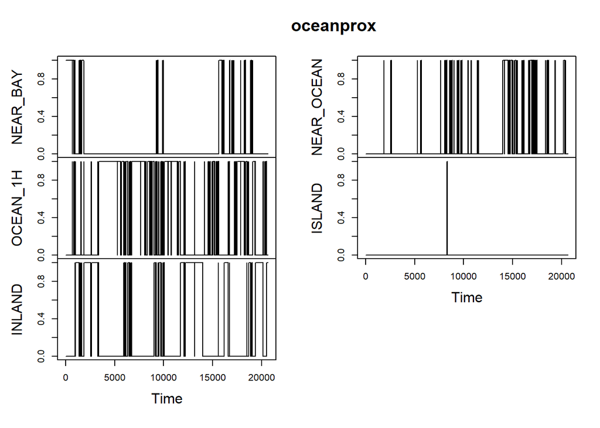

```r
plot.ts(oceanprox)
```